# circular-task-assignment

Circular task analysis

13 October 2025, 22:15:07

by Denis Mottet (and Copilot)

The task is described in [Fauviaux et al. (2021)](https://hal.science/hal-03834500). The data was recorded with the MouseReMoCo software.

To understand how the data was recorded, you are invited to play with MouseReMoCo on you own computer. Once you really understand how the task works, what is recorded and how to interpret the content of the data files, you can start working on the codding part of this assignment.

**NOTE:** The coding part of this assignment is not the difficult part. The difficult part is to understand how the data was recorded and how to interpret the content of the data files. So please, take your time to understand the task, carefully read the documentation in the GitHub repository, and explore the task and the data generated on your own computer before starting coding.

Your mission is to:

- reproduce the graphics below, using the data files provided in the assignment (`001MoDe_R1.csv` and `001MoDe_R1.markers.csv`).
- re-compute the values in the table at the end of `001MoDe_R1.markers.csv` file using your own code to analyze the data in `001MoDe_R1.csv`.
- run your code on a data file that you generated yourself with *MouseReMoCo*, and include the results in your report.
- write a short HTML report (1-2 pages) explaining the most interesting difficulties you encountered and solved, and how you verified that your results are correct.

You will work in teams of 3 students to deliver a public GitHub repository containing your circular task analysis.

# Advice for managing your GitHub repository

Take your time to re-explore the Python-for-HMS-Template repository and understand its structure, components, and how it can be utilized for your specific needs.

In each team, decide on one member to manage the project. The manager will be responsible for creating the GitHub repository and ensuring that all team members have access. The manager will also oversee the integration of contributions from all team members, and will be the **only one to merge** pull requests (i.e., be the assignee).

Each team member should create a new branch for their work. Once a member has completed their analysis or coding task, they should create a pull request to merge their branch into the main branch, asking for the review of the other team members.

Avoid working in parallel on the same files to minimize merge conflicts. If conflicts do arise, the manager will handle them during the merging process.

# Code snippets to get you started

```python
# imports (this is all you need for this assignment - please, do not import anything else)
import numpy as np
import matplotlib.pyplot as plt
import os

# very useful for zoomable plots in Jupyter notebooks
%matplotlib widget

# import pandas as pd # we do not use pandas here
```

```python
# if the present working directory is the directory of this file, change the path to the project root
if os.getcwd().endswith("notebooks"):
    os.chdir("..")
```

# Expected results

[output not shown]

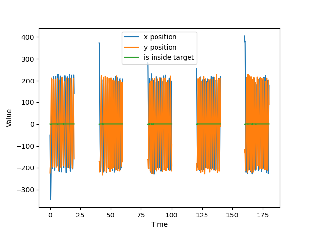

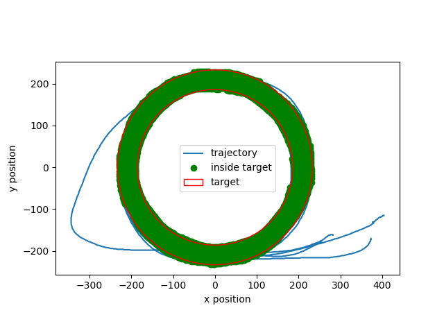

```
Number of records: 5
record 0: 3971 samples in 19.98 s (198.68 Hz)
record 1: 3898 samples in 19.59 s (198.94 Hz)
record 2: 3898 samples in 19.68 s (198.03 Hz)
record 3: 3884 samples in 19.46 s (199.53 Hz)
record 4: 3936 samples in 19.95 s (197.22 Hz)
```

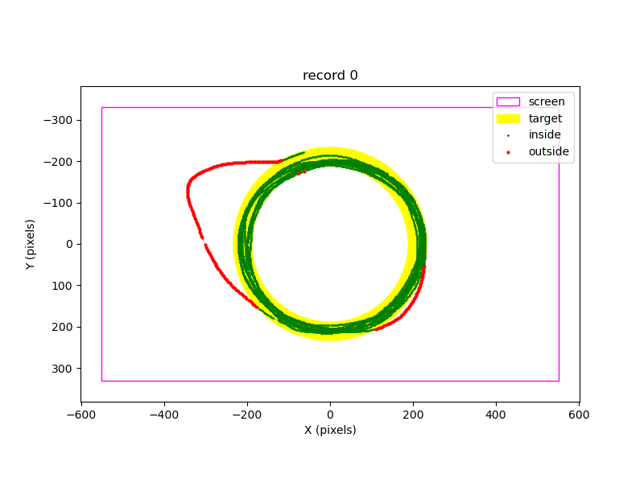

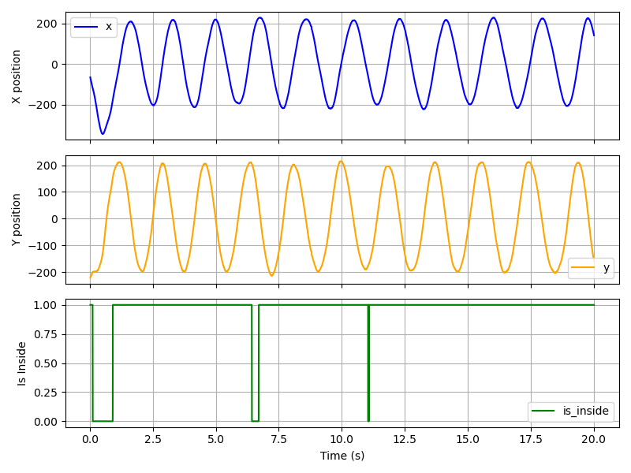

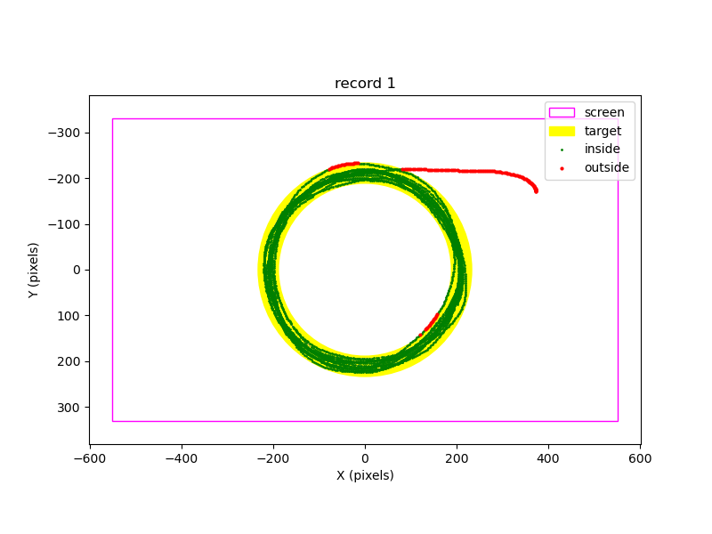

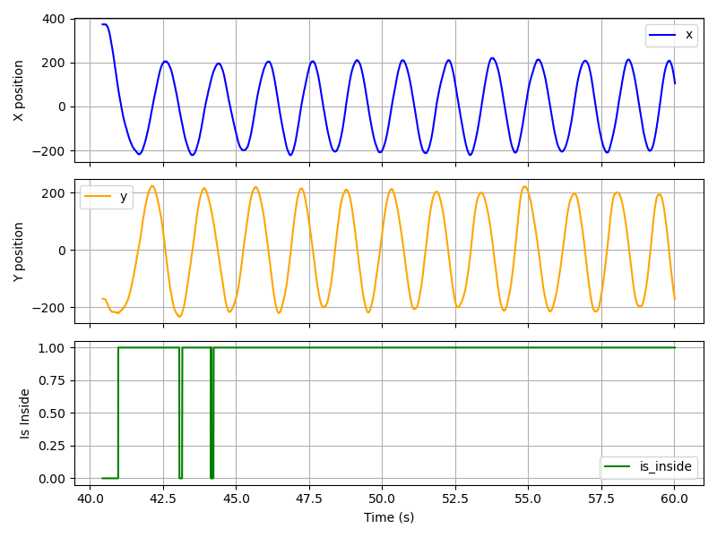

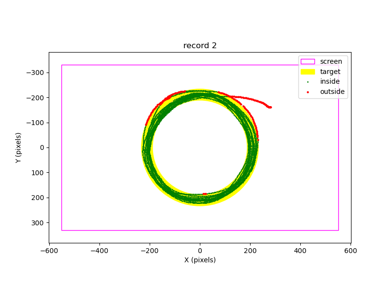

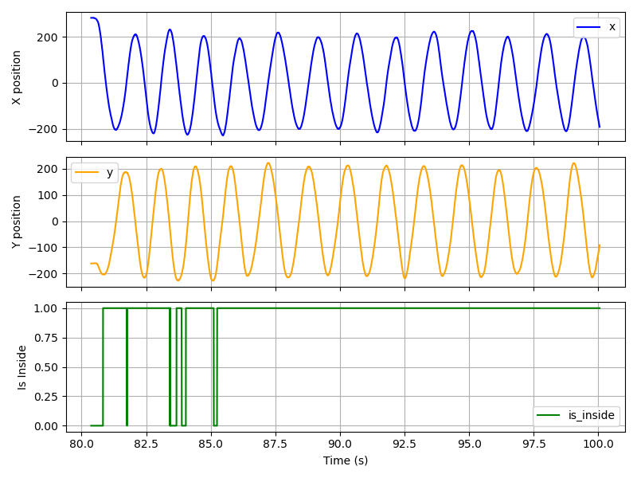

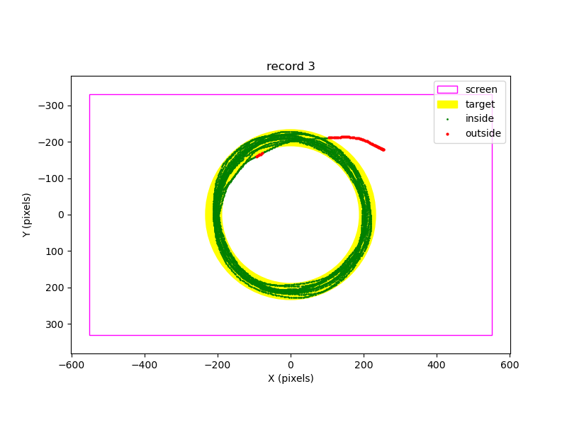

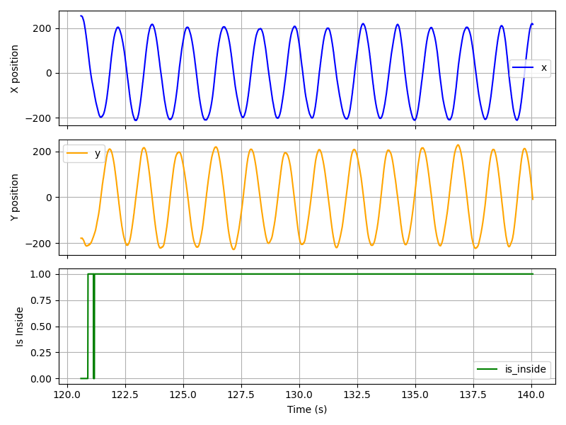

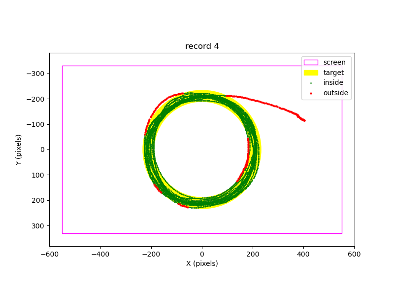

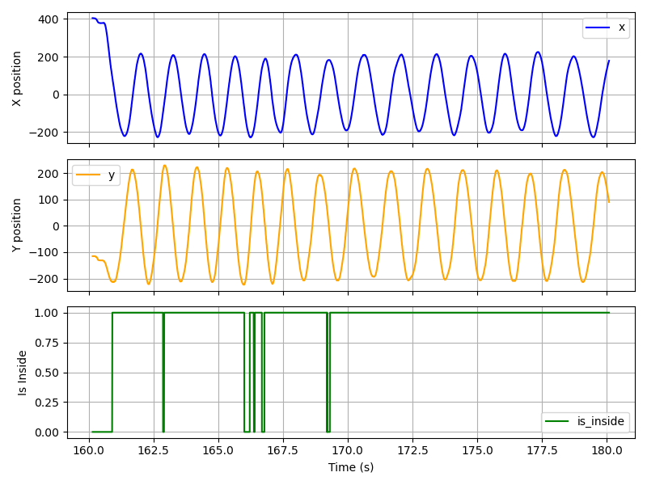